# Validación del modelo en Regresión Múltiple

Rodolfo Fernández de Lara (estructurado con ChatGPT)

ago 2024

1. Linealidad

El supuesto de linealidad establece que la relación entre las variables independientes y la variable dependiente debe ser lineal. Verificación

```
Gráfico de residuos estandarizados contra valores predichos: Un patrón aleatorio alrededor de la línea cero sugiere linealidad.
Prueba de RESET de Ramsey: Evalúa si hay términos omitidos que podrían indicar una relación no lineal.
```

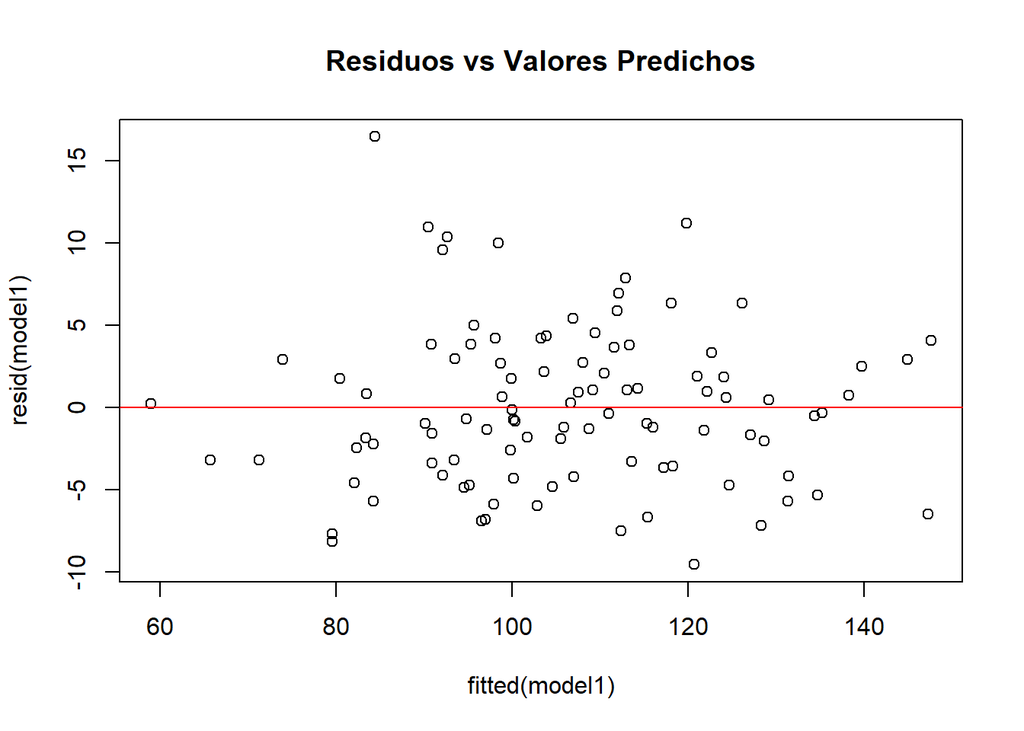

```r
# Ejemplo donde se cumple el supuesto
set.seed(123)
x <- rnorm(100, 50, 10)
y <- 5 + 2 * x + rnorm(100, 0, 5)
model1 <- lm(y ~ x)
plot(fitted(model1), resid(model1), main = "Residuos vs Valores Predichos")
abline(h = 0, col = "red")
```

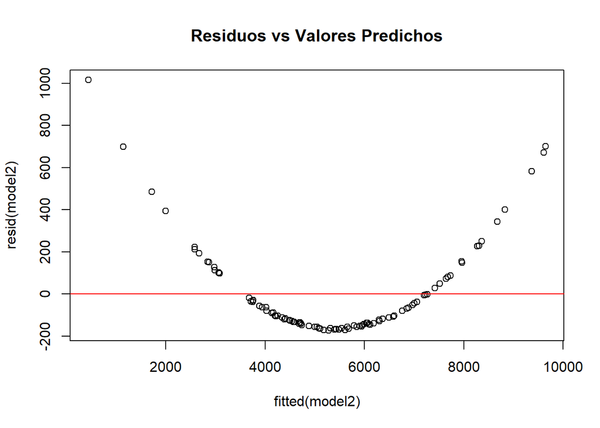

```r
# Ejemplo donde no se cumple el supuesto
y <- 5 + 2 * x^2 + rnorm(100, 0, 5)
model2 <- lm(y ~ x)
plot(fitted(model2), resid(model2), main = "Residuos vs Valores Predichos")
abline(h = 0, col = "red")

# Prueba de RESET de Ramsey
library(lmtest)
```

```r
resettest(model2)
```

```
##
##  RESET test
##
## data:  model2
## RESET = 112786, df1 = 2, df2 = 96, p-value < 2.2e-16
```

Cómo lidiar con la no linealidad

Si el supuesto de linealidad no se cumple, se pueden agregar términos polinomiales o utilizar la prueba de RESET de Ramsey para identificar la necesidad de estos términos.

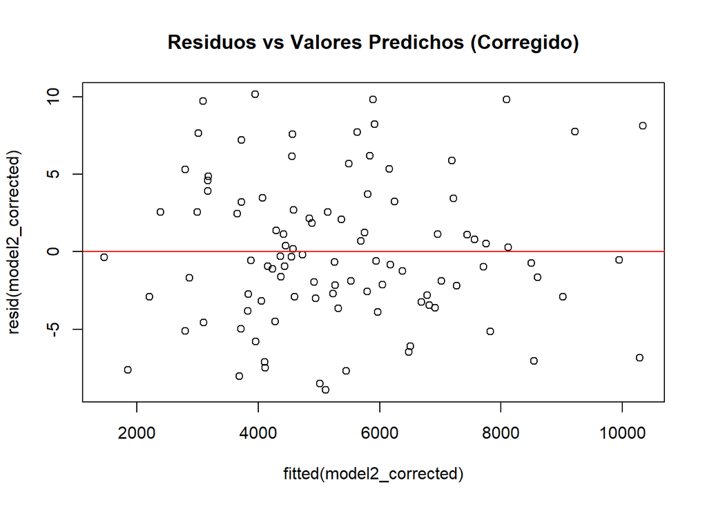

```r
# Ajuste con términos polinomiales
model2_corrected <- lm(y ~ poly(x, 2))
plot(fitted(model2_corrected), resid(model2_corrected), main = "Residuos vs Valores Predichos (Corregido)")
abline(h = 0, col = "red")
```

2. Independencia de errores

Los errores deben ser independientes entre sí. La autocorrelación en los errores puede invalidar los resultados del modelo. Verificación

```
Test de Durbin-Watson: Un valor cercano a 2 indica independencia.
Prueba Breusch-Godfrey: Evalúa la autocorrelación de los residuos de órdenes superiores.
```

Hipótesis

```
H₀: Los errores no están autocorrelacionados.
H₁: Los errores están autocorrelacionados.
```

Estadístico de prueba

```
La ecuación para el estadístico de Durbin-Watson es:
```

$$DW = \frac{\sum_{t=2}^{n} (e_t - e_{t-1})^2}{\sum_{t=1}^{n} e_t^2}$$

Un valor cercano a 2 sugiere independencia.

```r
# Ejemplo donde se cumple el supuesto
y <- 5 + 2 * x + rnorm(100, 0, 5)
model1 <- lm(y ~ x)
dwtest(model1)
```

```
##
##  Durbin-Watson test
##
## data:  model1
## DW = 2.1604, p-value = 0.7913
## alternative hypothesis: true autocorrelation is greater than 0
```

```r
bgtest(model1)
```

```
##
##  Breusch-Godfrey test for serial correlation of order up to 1
##
## data:  model1
## LM test = 0.6937, df = 1, p-value = 0.4049
```

```r
# Ejemplo donde no se cumple el supuesto
y[1] <- 5 + 2 * x[1] + rnorm(1, 0, 5)
for (i in 2:100) {
  y[i] <- 0.8 * y[i-1] + 2 * x[i] + rnorm(1, 0, 5)
}
model2 <- lm(y ~ x)
dwtest(model2)
```

```
##
##  Durbin-Watson test
##
## data:  model2
## DW = 0.079688, p-value < 2.2e-16
## alternative hypothesis: true autocorrelation is greater than 0
```

```r
bgtest(model2)
```

```
##
##  Breusch-Godfrey test for serial correlation of order up to 1
##
## data:  model2
## LM test = 64.745, df = 1, p-value = 8.525e-16
```

Cómo lidiar con la autocorrelación

Si hay autocorrelación, se puede ajustar un modelo de regresión con errores autocorrelacionados, como un modelo ARIMA.

```r
library(forecast)
model2_arima <- auto.arima(y, xreg = x)
summary(model2_arima)
```

```
## Series: y
## Regression with ARIMA(0,2,2) errors
##
## Coefficients:
##           ma1      ma2    xreg
##       -0.2764  -0.3631  1.0770
## s.e.   0.0963   0.0983  0.0721
##
## sigma^2 = 192.6:  log likelihood = -395.55
## AIC=799.09   AICc=799.52   BIC=809.43
##
## Training set error measures:
##                     ME     RMSE      MAE        MPE    MAPE      MASE
## Training set -1.893198 13.52648 10.36509 -0.4477933 2.12107 0.5951177
##                     ACF1
## Training set -0.02640259
```

3. Homoscedasticidad

La varianza de los errores debe ser constante. La heterocedasticidad puede distorsionar las inferencias. Verificación

```
Gráfico de residuos estandarizados contra valores predichos: Un patrón uniforme sugiere homocedasticidad.
Test de Breusch-Pagan: Evalúa la constancia de la varianza.
Test de White: Prueba más robusta que no asume una forma específica de la heterocedasticidad.
```

Hipótesis

```
H₀: La varianza de los errores es constante (homocedasticidad).
H₁: La varianza de los errores no es constante (heterocedasticidad).
```

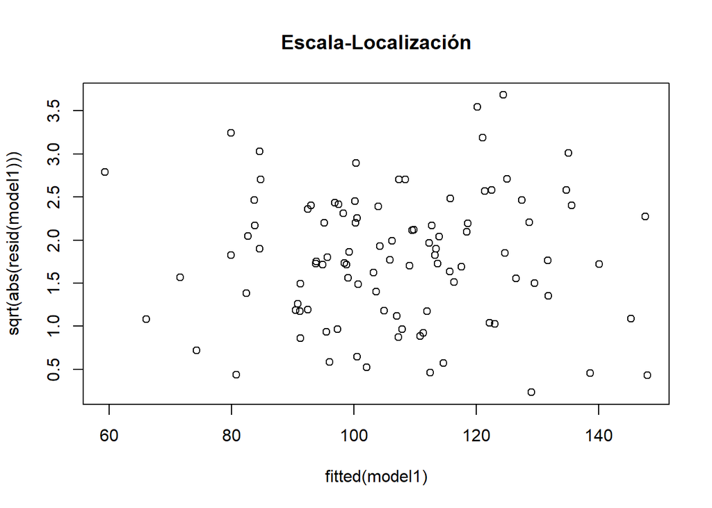

```r
# Ejemplo donde se cumple el supuesto
y <- 5 + 2 * x + rnorm(100, 0, 5)
model1 <- lm(y ~ x)
plot(fitted(model1), sqrt(abs(resid(model1))), main = "Escala-Localización")
abline(h = 0, col = "red")
```

```r
bptest(model1)
```

```
##
##  studentized Breusch-Pagan test
##
## data:  model1
## BP = 0.4037, df = 1, p-value = 0.5252
```

```r
gqtest(model1)
```

```
##
##  Goldfeld-Quandt test
##
## data:  model1
## GQ = 1.1921, df1 = 48, df2 = 48, p-value = 0.2725
## alternative hypothesis: variance increases from segment 1 to 2
```

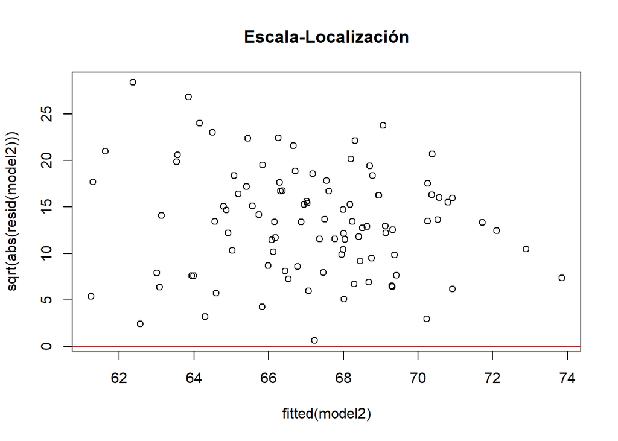

```r
# Ejemplo donde no se cumple el supuesto
y <- 5 + 2 * x + rnorm(100, 0, 5 * x)
model2 <- lm(y ~ x)
plot(fitted(model2), sqrt(abs(resid(model2))), main = "Escala-Localización")
abline(h = 0, col = "red")
```

```r
bptest(model2)
```

```
##
##  studentized Breusch-Pagan test
##
## data:  model2
## BP = 7.0871, df = 1, p-value = 0.007764
```

```r
gqtest(model2)
```

```
##
##  Goldfeld-Quandt test
##
## data:  model2
## GQ = 0.97086, df1 = 48, df2 = 48, p-value = 0.5406
## alternative hypothesis: variance increases from segment 1 to 2
```

Cómo lidiar con la heterocedasticidad

Para corregir la heterocedasticidad, se puede aplicar una transformación logarítmica o utilizar regresión robusta.

```r
# Transformación logarítmica
model2_log <- lm(log(y) ~ x)
```

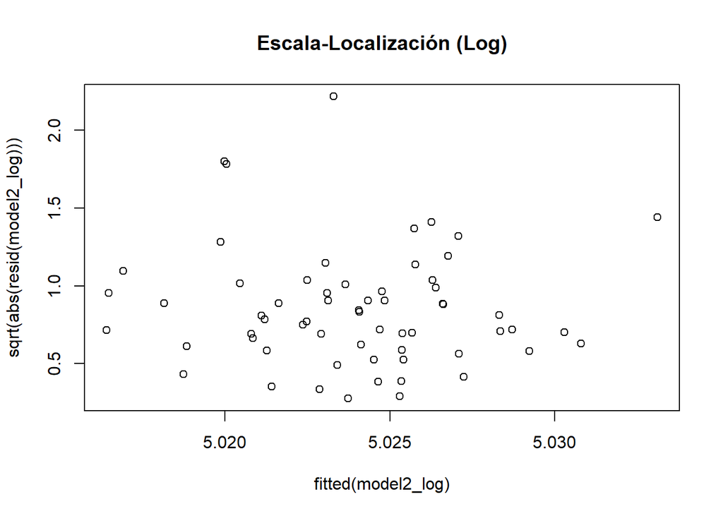

```r
plot(fitted(model2_log), sqrt(abs(resid(model2_log))), main = "Escala-Localización (Log)")
abline(h = 0, col = "red")
```

```r
# Regresión robusta
library(MASS)
model2_robust <- rlm(y ~ x)
summary(model2_robust)
```

```
##
## Call: rlm(formula = y ~ x)
## Residuals:
##     Min      1Q  Median      3Q     Max
## -832.04 -163.78   11.28  185.56  698.23
##
## Coefficients:
##             Value    Std. Error t value
## (Intercept)  19.2035 152.4259     0.1260
## x             1.0416   2.9478     0.3534
##
## Residual standard error: 270 on 98 degrees of freedom
```

4. Normalidad de los errores

Los errores deben seguir una distribución normal para que las inferencias basadas en el modelo sean válidas. Verificación

```
Q-Q plot: Si los puntos siguen una línea recta, los errores son normales.
Test de Shapiro-Wilk: Evalúa la normalidad de los residuos.
Test de Kolmogorov-Smirnov: Otra prueba para verificar la normalidad.
```

Hipótesis

```
H₀: Los errores siguen una distribución normal.
H₁: Los errores no siguen una distribución normal.
```

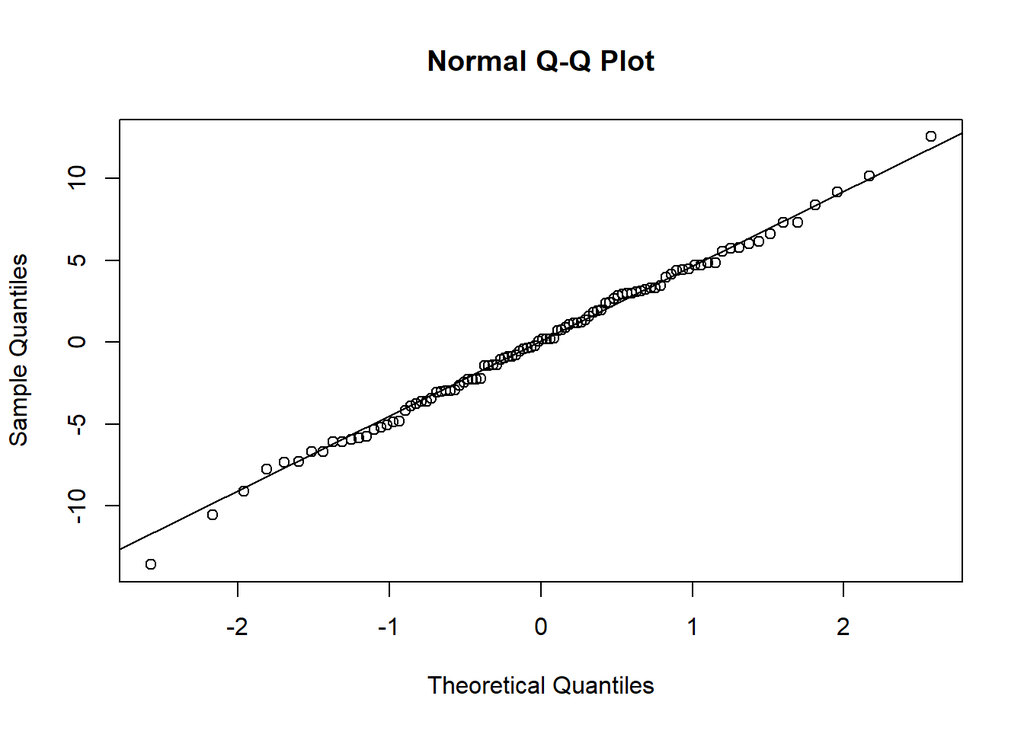

```r
# Ejemplo donde se cumple el supuesto
qqnorm(resid(model1))
qqline(resid(model1))
```

```r
shapiro.test(resid(model1))
```

```
##
##  Shapiro-Wilk normality test
##
## data:  resid(model1)
## W = 0.99713, p-value = 0.9993
```

```r
ks.test(resid(model1), "pnorm", mean = mean(resid(model1)), sd = sd(resid(model1)))
```

```
##
##  Asymptotic one-sample Kolmogorov-Smirnov test
##
## data:  resid(model1)
## D = 0.039573, p-value = 0.9976
## alternative hypothesis: two-sided
```

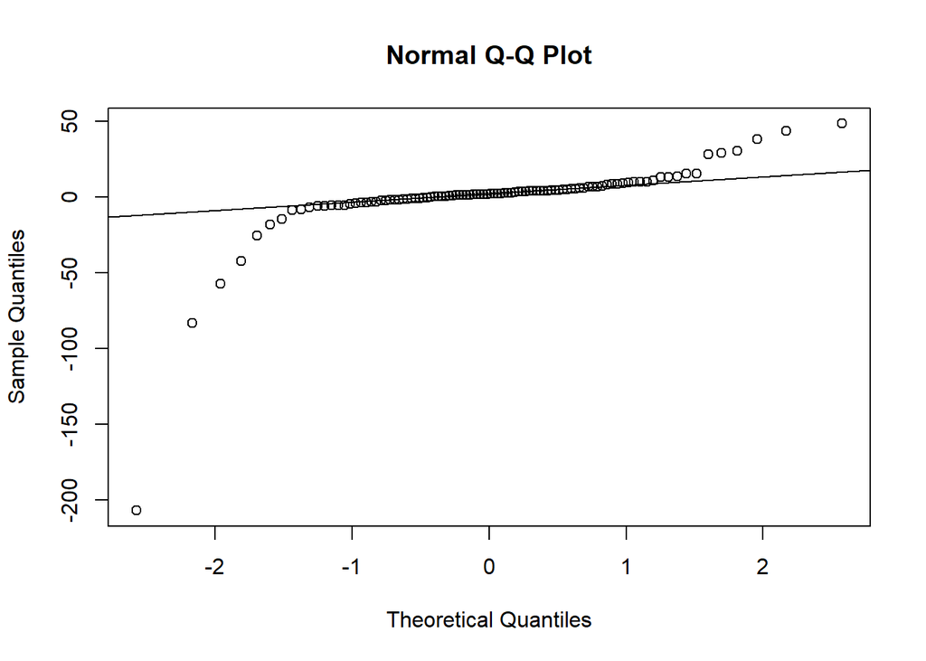

```r
# Ejemplo donde no se cumple el supuesto
y <- 5 + 2 * x + rt(100, df = 2) * 5  # Distribución t con df bajos para mayor cola
model2 <- lm(y ~ x)
qqnorm(resid(model2))
qqline(resid(model2))
```

```r
shapiro.test(resid(model2))
```

```
##
##  Shapiro-Wilk normality test
##
## data:  resid(model2)
## W = 0.49186, p-value < 2.2e-16
```

```r
ks.test(resid(model2), "pnorm", mean = mean(resid(model2)), sd = sd(resid(model2)))
```

```
##
##  Asymptotic one-sample Kolmogorov-Smirnov test
##
## data:  resid(model2)
## D = 0.3093, p-value = 9.811e-09
## alternative hypothesis: two-sided
```

Cómo lidiar con la no normalidad

Se pueden realizar transformaciones en la variable dependiente o utilizar métodos robustos.

```r
# Transformación logarítmica
model2_log <- lm(log(y) ~ x)
```

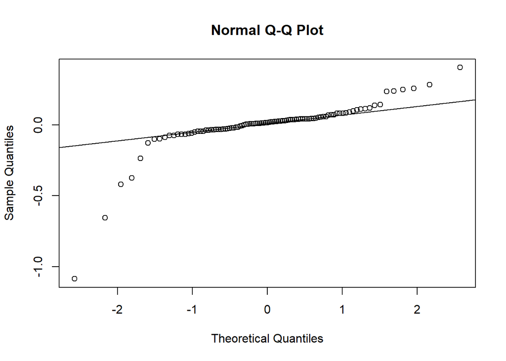

```r
qqnorm(resid(model2_log))
qqline(resid(model2_log))
```

```r
# Modelos robustos
library(MASS)
model2_robust <- rlm(y ~ x)
summary(model2_robust)
```

```
##
## Call: rlm(formula = y ~ x)
## Residuals:
##        Min         1Q     Median         3Q        Max
## -209.22506   -3.77498    0.02691    3.82380   46.49376
##
## Coefficients:
##             Value   Std. Error t value
## (Intercept) 10.5195  4.0683     2.5857
## x            1.8951  0.0787    24.0858
##
## Residual standard error: 5.679 on 98 degrees of freedom
```

5. Ausencia de multicolinealidad

No debe existir una colinealidad perfecta o casi perfecta entre las variables independientes, ya que esto puede distorsionar los resultados del modelo. Verificación

```
Factor de inflación de la varianza (VIF): Valores superiores a 10 indican multicolinealidad preocupante.
Condición del número: Un valor alto indica multicolinealidad.
Eigenvalues y eigenvectors: Análisis más detallado de la colinealidad.
```

```r
# Ejemplo donde se cumple el supuesto
x1 <- rnorm(100, 50, 10)
x2 <- rnorm(100, 30, 5)
y <- 5 + 2 * x1 + 3 * x2 + rnorm(100, 0, 5)
model1 <- lm(y ~ x1 + x2)
library(car)
vif(model1)
```

```
##       x1       x2
## 1.002399 1.002399
```

```r
# Ejemplo donde no se cumple el supuesto
x2 <- x1 + rnorm(100, 0, 1)  # x2 altamente correlacionada con x1
model2 <- lm(y ~ x1 + x2)
vif(model2)
```

```
##       x1       x2
## 102.3973 102.3973
```

Cómo lidiar con la multicolinealidad

Para manejar la multicolinealidad, se puede eliminar una de las variables correlacionadas o utilizar el análisis de componentes principales (PCA).

```r
# Eliminando una variable
model2_reduced <- lm(y ~ x1)
summary(model2_reduced)
```

```
##
## Call:
## lm(formula = y ~ x1)
##
## Residuals:
##     Min      1Q  Median      3Q     Max
## -38.444 -10.631   0.565   9.568  52.529
##
## Coefficients:
##             Estimate Std. Error t value Pr(>|t|)
## (Intercept)  91.4156     8.4782   10.78   <2e-16 ***
## x1            2.0593     0.1624   12.68   <2e-16 ***
## ---
## Signif. codes:  0 '***' 0.001 '**' 0.01 '*' 0.05 '.' 0.1 ' ' 1
##
## Residual standard error: 16.26 on 98 degrees of freedom
## Multiple R-squared:  0.6212, Adjusted R-squared:  0.6173
## F-statistic: 160.7 on 1 and 98 DF,  p-value: < 2.2e-16
```

```r
# Análisis de componentes principales
library(stats)
pca <- prcomp(cbind(x1, x2), scale. = TRUE)
summary(pca)
```

```
## Importance of components:
##                           PC1     PC2
## Standard deviation     1.4125 0.06996
## Proportion of Variance 0.9976 0.00245
## Cumulative Proportion  0.9976 1.00000
```

6. Ausencia de valores atípicos influyentes

No debe haber valores atípicos que influyan desproporcionadamente en los resultados del modelo. Verificación

```
Distancia de Cook: Valores superiores a 1 indican observaciones influyentes.
Leverage y DFBETAS: Evaluación adicional de la influencia de los datos.
Gráfico de apalancamiento y residuos: Para identificar puntos influyentes.
```

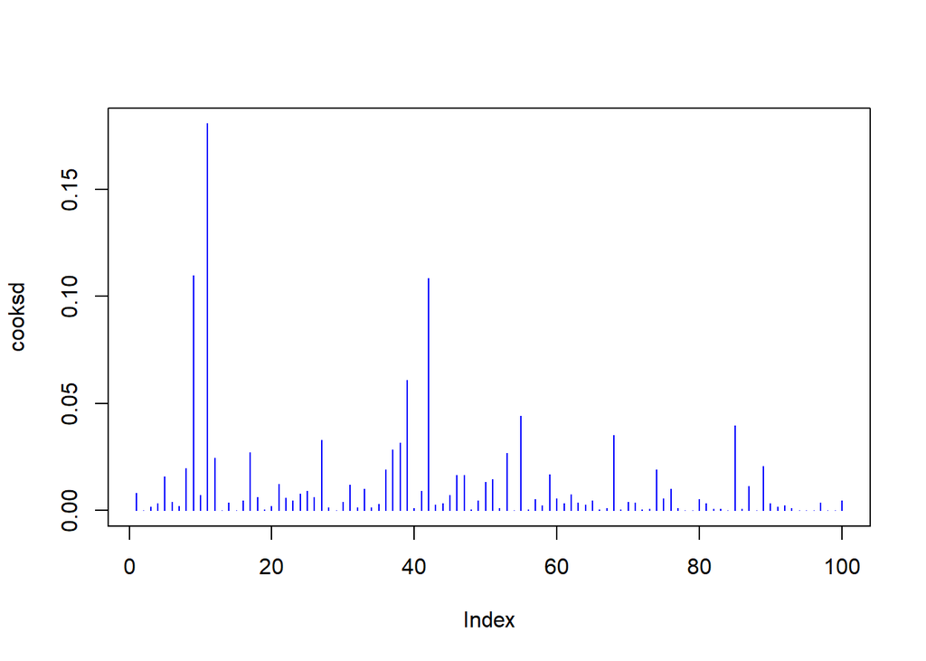

```r
# Ejemplo donde se cumple el supuesto
cooksd <- cooks.distance(model1)
plot(cooksd, type = "h", col = "blue")
abline(h = 1, col = "red")
```

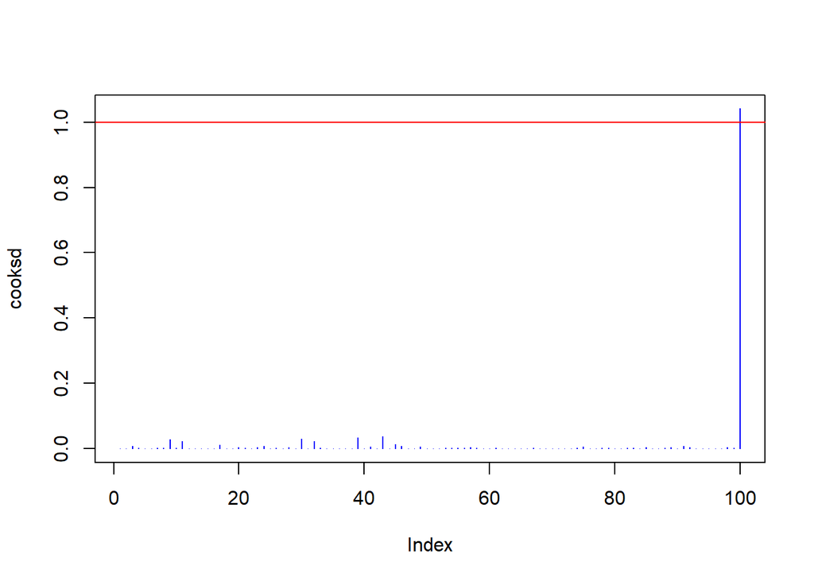

```r
# Ejemplo donde no se cumple el supuesto
y[100] <- 500  # Un valor atípico muy influyente
model2 <- lm(y ~ x1 + x2)
cooksd <- cooks.distance(model2)
plot(cooksd, type = "h", col = "blue")
abline(h = 1, col = "red")
```

Cómo lidiar con los valores atípicos influyentes

Se puede eliminar el valor atípico o usar métodos robustos para minimizar su influencia.

```r
# Eliminar la observación atípica
model2_reduced <- lm(y[-100] ~ x1[-100] + x2[-100])
summary(model2_reduced)
```

```
##
## Call:
## lm(formula = y[-100] ~ x1[-100] + x2[-100])
##
## Residuals:
##     Min      1Q  Median      3Q     Max
## -39.032 -11.504   1.726   9.869  49.380
##
## Coefficients:
##             Estimate Std. Error t value Pr(>|t|)
## (Intercept)   94.901      8.647   10.98   <2e-16 ***
## x1[-100]      -1.348      1.623   -0.83   0.4086
## x2[-100]       3.346      1.586    2.11   0.0374 *
## ---
## Signif. codes:  0 '***' 0.001 '**' 0.01 '*' 0.05 '.' 0.1 ' ' 1
##
## Residual standard error: 16.06 on 96 degrees of freedom
## Multiple R-squared:  0.6311, Adjusted R-squared:  0.6234
## F-statistic: 82.12 on 2 and 96 DF,  p-value: < 2.2e-16
```

```r
# Regresión robusta
model2_robust <- rlm(y ~ x1 + x2)
summary(model2_robust)
```

```
##
## Call: rlm(formula = y ~ x1 + x2)
## Residuals:
##     Min      1Q  Median      3Q     Max
## -40.856 -11.965   1.079  10.712 263.626
##
## Coefficients:
##             Value   Std. Error t value
## (Intercept) 89.2353  8.8851    10.0433
## x1          -1.0628  1.6873    -0.6299
## x2           3.1732  1.6475     1.9261
##
## Residual standard error: 16.56 on 97 degrees of freedom
```